# liga2

[figure not shown]

[figure not shown]

**LIGAÇÃO II**

Prof. Saulo Chaves

ESALQ / USP - Departamento de Genética

LGN 215 - Genética

## Anteriormente em LGN0215

Genes ligados encontram-se próximos no mesmo cromossomo, e sua segregação não é independente

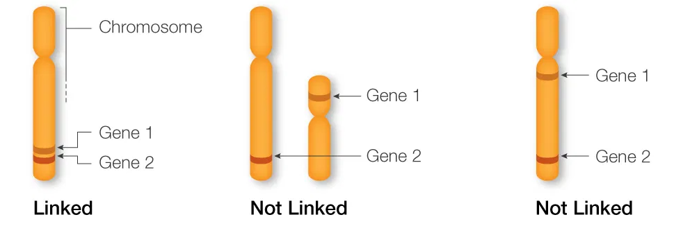

[University of Utah](https://learn.genetics.utah.edu/content/pigeons/geneticlinkage/)

## Anteriormente em LGN0215

A ocorrência de gametas recombinantes se dá pela ocorrência de *crossing-overs* entre genes parcialmente ligados

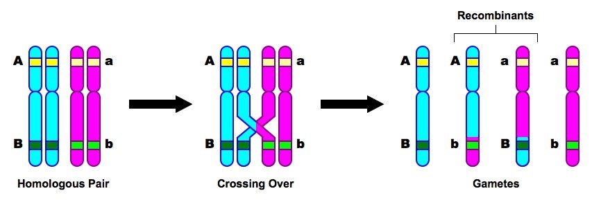

[BioNinja](https://ib.bioninja.com.au/higher-level/topic-10-genetics/102-dihybrid-crosses-and.html)

## Anteriormente em LGN0215

Quanto maior a ocorrência de *crossing-overs*, maior a frequência de recombinantes. Por isso, tal frequência é um indicador de distância entre genes utilizado para a construção de mapas de ligação

[figure not shown]

[Twaanders17/Wiki](https://en.m.wikipedia.org/wiki/File:Drosophila_Gene_Linkage_Map.svg)

## Conteúdo de hoje

1. Teste de três pontos
   - Por que e como utilizar?
2. Interferência
   - Coeficiente de coincidência
3. Marcadores genéticos
   - Marcadores morfológicos
   - Marcadores moleculares

# Teste de três pontos

## Cruzamento-teste de dois pontos

**AB/ab** $\times$ **ab/ab**

| Gen. | Nº ind. |
| --- | --- |
| AB/ab | 252 |
| ab/ab | 249 |
| Ab/ab | 251 |
| aB/ab | 248 |

**aC/Ac** $\times$ **ac/ac**

| Gen. | Nº ind. |
| --- | --- |
| AC/ac | 255 |
| ac/ac | 245 |
| Ac/ac | 258 |
| aC/ac | 242 |

**BC/bc** $\times$ **bc/bc**

| Gen. | Nº ind. |
| --- | --- |
| BC/bc | 405 |
| bc/bc | 395 |
| Bc/bc | 102 |
| bC/bc | 98 |

## Cruzamento-teste de dois pontos

**bD/Bd** $\times$ **bd/bd**

| Gen. | Nº ind. |
| --- | --- |
| BD/bd | 58 |
| bd/bd | 42 |
| Bd/bd | 454 |
| bD/bd | 436 |

**CD/cd** $\times$ **cd/cd**

| Gen. | Nº ind. |
| --- | --- |
| CD/cd | 435 |
| cd/cd | 425 |
| Cd/cd | 160 |
| cD/cd | 162 |

## Cruzamento-teste de dois pontos

[figure not shown]

## Cruzamento-teste de dois pontos

- **Pouco eficientes no estabelecimento da ordem dos genes**: necessidade de um grande número de indivíduos e vários cruzamentos
- **Pouco eficientes na detecção de crossing-over duplos**: subestimação das distâncias no mapa

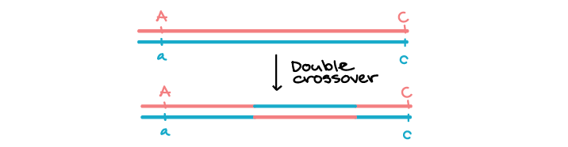

[Khan Academy](https://cdn.kastatic.org/ka-perseus-images/2b759e1e803dcfb6b8f97e4583d6438b4250eb10.png)

## Cruzamento-teste de três pontos

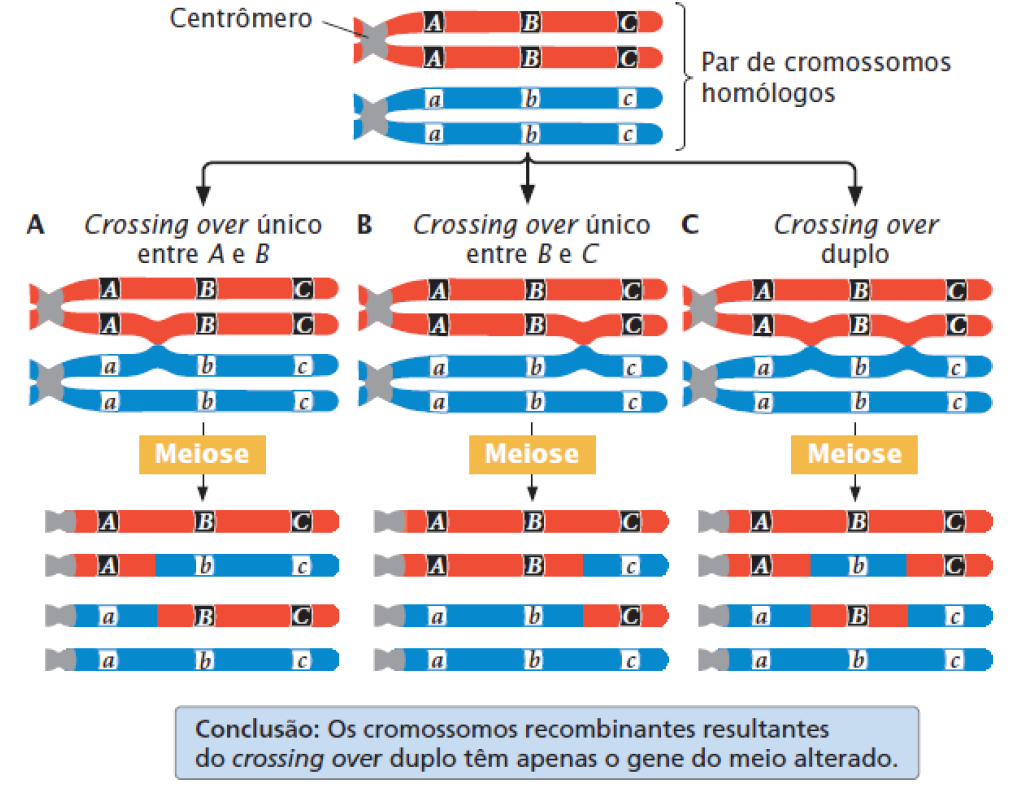

Pierce (2016)

## Cruzamento-teste de três pontos

- Cruzamentos entre triíbridos:

**abc/abc** $\times$ **ABC/ABC**

Gametas: **abc** e **ABC**

F<sub>1</sub> triíbrida: **ABC/abc**

- Deduzir se três genes estão ligados e, caso positivo, a ordem entre eles
- Ordem arbitrária!

## Cruzamento-teste de três pontos

F<sub>1</sub> triíbrida: **ABC/abc**

- Gametas possíveis: $2^n = 2 \times 2 \times 2 = 8$

[figure not shown]

## Cruzamento-teste de três pontos

Quais são os gametas recombinantes?

| Gametas | Recombinantes em relação aos locos: A e B | Recombinantes em relação aos locos: A e C | Recombinantes em relação aos locos: B e C |
| --- | --- | --- | --- |
| ABC |  |  |  |
| aBC | R | R |  |
| AbC | R |  | R |
| abC |  | R | R |
| ABc |  | R | R |
| aBc | R |  | R |
| Abc | R | R |  |
| abc |  |  |  |

## Cruzamento-teste de três pontos

**ABC/abc** $\times$ **abc/abc**

| Gametas | Recombinantes em relação aos locos: A e B | Recombinantes em relação aos locos: A e C | Recombinantes em relação aos locos: B e C | Cruzamento-teste | Nº ind. |  |  |
| --- | --- | --- | --- | --- | --- | --- | --- |
| ABC |  |  |  |  |  | ABC/abc | 235 |
| aBC | R | R |  | aBC/abc | 14 |  |  |
| AbC | R |  | R | AbC/abc | 14 |  |  |
| abC |  | R | R | abC/abc | 243 |  |  |
| ABc |  | R | R | ABc/abc | 233 |  |  |
| aBc | R |  | R | aBc/abc | 12 |  |  |
| Abc | R | R |  | Abc/abc | 16 |  |  |
| abc |  |  |  | abc/abc | 241 |  |  |

## Cruzamento-teste de três pontos

| Gametas | A e B | A e C | B e C | Nº ind. |
| --- | --- | --- | --- | --- |
| ABC |  |  |  | 235 |
| aBC | R | R |  | 14 |
| AbC | R |  | R | 14 |
| abC |  | R | R | 243 |
| ABc |  | R | R | 233 |
| aBc | R |  | R | 12 |
| Abc | R | R |  | 16 |
| abc |  |  |  | 241 |

$$\begin{split}
FR_{AB} & = \frac{14+14+12+16}{1008} \\
& = \frac{56}{1008} \\
& = 0,055 \times 100 \\
& = 5,5 \mbox{ cM}
\end{split}$$

Genes ligados!

## Cruzamento-teste de três pontos

| Gametas | A e B | A e C | B e C | Nº ind. |
| --- | --- | --- | --- | --- |
| ABC |  |  |  | 235 |
| aBC | R | R |  | 14 |
| AbC | R |  | R | 14 |
| abC |  | R | R | 243 |
| ABc |  | R | R | 233 |
| aBc | R |  | R | 12 |
| Abc | R | R |  | 16 |
| abc |  |  |  | 241 |

$$\begin{split}
FR_{AC} & = \frac{14+243+233+16}{1008} \\
& = \frac{506}{1008} \\
& = 0,502 \times 100 \\
& = 50,2 \mbox{ cM}
\end{split}$$

Genes independentes!

## Cruzamento-teste de três pontos

| Gametas | A e B | A e C | B e C | Nº ind. |
| --- | --- | --- | --- | --- |
| ABC |  |  |  | 235 |
| aBC | R | R |  | 14 |
| AbC | R |  | R | 14 |
| abC |  | R | R | 243 |
| ABc |  | R | R | 233 |
| aBc | R |  | R | 12 |
| Abc | R | R |  | 16 |
| abc |  |  |  | 241 |

$$\begin{split}
FR_{BC} & = \frac{14+243+233+12}{1008} \\
& = \frac{502}{1008} \\
& = 0,498 \times 100 \\
& = 49,8 \mbox{ cM}
\end{split}$$

Genes independentes!

## Cruzamento-teste de três pontos

[figure not shown]

- Genótipos dos genitores corrigido:

$$AB/AB; C/C \times ab/ab;c/c$$

- Na vida real, é importante testar a hipótese de ligação entre genes $(FR = 50 \mbox{ cM})$

## Cruzamento-teste de três pontos

- Exemplo com genes ligados

**dEF/dEF** $\times$ **Def/Def**

Gametas: **dEF** e **Def**

F<sub>1</sub> triíbrida: **dEF/Def**

Quais os gametas da $F_1$?

## Cruzamento-teste de três pontos

Quais são os gametas recombinantes?

| Gametas | Recombinantes em relação aos locos D e E | Recombinantes em relação aos locos D e F | Recombinantes em relação aos locos E e F |
| --- | --- | --- | --- |
| DEF | R | R |  |
| dEF |  |  |  |
| DeF |  | R | R |
| deF | R |  | R |
| DEf | R |  | R |
| dEf |  | R | R |
| Def |  |  |  |
| def | R | R |  |

## Cruzamento-teste de três pontos

**dEF/Def** $\times$ **def/def**

| Gametas | Recombinantes em relação aos locos D e E | Recombinantes em relação aos locos D e F | Recombinantes em relação aos locos E e F | Cruzamento-teste | Nº ind. |  |  |
| --- | --- | --- | --- | --- | --- | --- | --- |
| DEF | R | R |  |  |  | DEF/def | 94 |
| dEF |  |  |  | dEF/def | 580 |  |  |
| DeF |  | R | R | DeF/def | 5 |  |  |
| deF | R |  | R | deF/def | 45 |  |  |
| DEf | R |  | R | DEf/def | 40 |  |  |
| dEf |  | R | R | dEf/def | 3 |  |  |
| Def |  |  |  | Def/def | 592 |  |  |
| def | R | R |  | def/def | 89 |  |  |

## Cruzamento-teste de três pontos

| Gametas | D e E | D e F | E e F | Nº ind |
| --- | --- | --- | --- | --- |
| DEF | R | R |  | 94 |
| dEF |  |  |  | 580 |
| DeF |  | R | R | 5 |
| deF | R |  | R | 45 |
| DEf | R |  | R | 40 |
| dEf |  | R | R | 3 |
| Def |  |  |  | 592 |
| def | R | R |  | 89 |

Genes ligados!

## Cruzamento-teste de três pontos

| Gametas | D e E | D e F | E e F | Nº ind |
| --- | --- | --- | --- | --- |
| DEF | R | R |  | 94 |
| dEF |  |  |  | 580 |
| DeF |  | R | R | 5 |
| deF | R |  | R | 45 |
| DEf | R |  | R | 40 |
| dEf |  | R | R | 3 |
| Def |  |  |  | 592 |
| def | R | R |  | 89 |

$$\begin{split}
FR_{DF} & = \frac{94+5+3+89}{1448} \\
& = \frac{191}{1448}\\
& = 0,132 \times 100 \\
& = 13,2 \mbox{ cM}
\end{split}$$

Genes ligados!

## Cruzamento-teste de três pontos

| Gametas | D e E | D e F | E e F | Nº ind |
| --- | --- | --- | --- | --- |
| DEF | R | R |  | 94 |
| dEF |  |  |  | 580 |
| DeF |  | R | R | 5 |
| deF | R |  | R | 45 |
| DEf | R |  | R | 40 |
| dEf |  | R | R | 3 |
| Def |  |  |  | 592 |
| def | R | R |  | 89 |

$$\begin{split}
FR_{EF} & = \frac{5+45+40+3}{1448} \\
& = \frac{93}{1448} \\
& = 0,064 \times 100 \\
& = 6,4 \mbox{ cM}
\end{split}$$

Genes ligados!

## Cruzamento-teste de três pontos

[figure not shown]

- Ordem mais provável
- Corrigindo o genótipo dos pais, temos:

$$efD/efD \times EFd/EFd$$

## Cruzamento-teste de três pontos

**Dedução intuitiva da ordem dos genes**

Os duplo-recombinantes são mais raros, pois dependem da ocorrência de dois *crossing-overs*. Em geral, para três genes, existe somente uma ordem compatível com os supostos duplo-recombinantes identificados na população

[figure not shown]

## Cruzamento-teste de três pontos

**Dedução intuitiva da ordem dos genes:**

| Gametas | D e E | D e F | E e F | Nº ind | Classe |
| --- | --- | --- | --- | --- | --- |
| EFD | R | R |  | 94 | Recombinante |
| EFd |  |  |  | 580 | Parental |
| eFD |  | R | R | 5 | Duplo-recombinante |
| eFd | R |  | R | 45 | Recombinante |
| EfD | R |  | R | 40 | Recombinante |
| Efd |  | R | R | 3 | Duplo-recombinante |
| efD |  |  |  | 592 | Parental |
| efd | R | R |  | 89 | Recombinante |

## Cruzamento-teste de três pontos

**Frequência de recombinação após o ordenamento correto:**

| Gametas | D e E | D e F | E e F | Nº ind | Classe |
| --- | --- | --- | --- | --- | --- |
| EFD | R | R |  | 94 | Recombinante |
| EFd |  |  |  | 580 | Parental |
| eFD | R | R | R | 5 | Duplo-recombinante |
| eFd | R |  | R | 45 | Recombinante |
| EfD | R |  | R | 40 | Recombinante |
| Efd | R | R | R | 3 | Duplo-recombinante |
| efD |  |  |  | 592 | Parental |
| efd | R | R |  | 89 | Recombinante |

$$FR_{DE} = \frac{94 + \color{red}{5} + \color{red}{5} + 45 + 40 + \color{red}{3} + \color{red}{3} + 89}{1448} \times 100 = 19,6 \mbox{ cM}$$

# Interferência

## Interferência

Em geral, os *crossing-overs* inibem uns aos outros de um modo semelhante a uma interação, fenômeno denominado interferência. A intensidade deste fenômeno está em função da proximidade entre locos. Em outras palavras, um *crossing-over* reduz a probabilidade de outro *crossing-over* em uma região adjacente.

- Se os *crossing-overs* fossem independentes:

$$\Pr\left(\mbox{DR}\right) = \Pr \left( r_{EF} \right) \times \Pr \left( r_{FD} \right) = 0,064 \times 0,132 = 0,0084$$

$$\Pr\left(\mbox{DR}\right) \times N = 0,0084 \times 1448 \approx 12,2 \mbox{ DR}$$

## Interferência

- Nº de DR observados = 8
- Nº de DR esperados = 12,2
- Coeficiente de coincidência $(C)$
  $$C = \frac{\mbox{Nº de DR observados}}{\mbox{Nº de DR esperados}} = \frac{8}{12,2} = 0,656$$
- Interferência $(I)$:
  $$I = 1 - C = 1 - 0,656 = 0,344 \mbox{ ou } 34,4\%$$

34,4% dos duplo recombinantes esperados não serão observados devido à interferência

## Funções de mapeamento

**Crossing-overs múltiplos podem ser indetectáveis**:

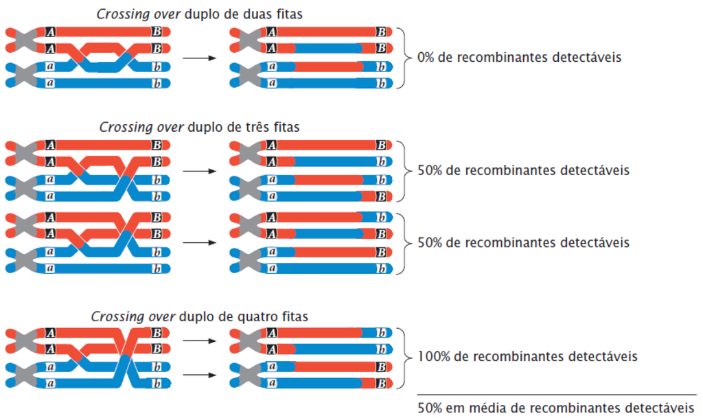

Pierce (2016)

## Funções de mapeamento

**Funções de mapeamento**: levam em consideração a ocorrência de crossing-overs múltiplos na conversão da fração de recombinação em distância em unidades de mapa

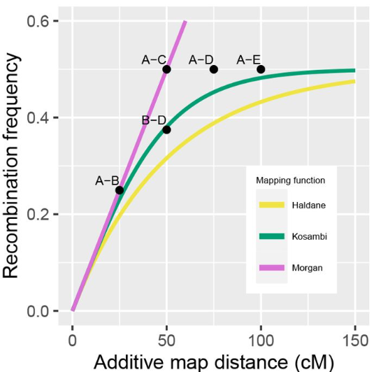

[Kivikoski et al. (2022)](https://www.nature.com/articles/s41437-022-00585-3)

# Marcadores genéticos

## Marcadores genéticos

- Marcos que indicam a existência de variações no DNA
  - Polimórficos
  - Facilmente identificáveis
  - Herdáveis
- Interessantes quando o marcador está ligado à um alelo de identificação/expressão complexa
  - Estudo/seleção indireta

## Marcadores morfológicos

- Fenótipo de fácil identificação
- Exemplo: nanismo e macho-esterilidade em trigo
  - Gene *Rht-D1c*: nanismo
  - Gene *Ms2*: macho-esterilidade

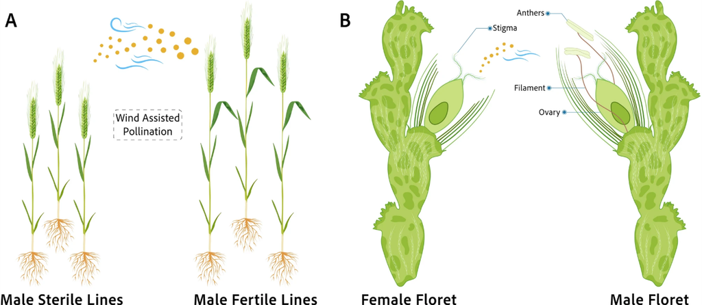

[Abdullah et al. (2025)](https://thericejournal.springeropen.com/articles/10.1186/s12284-025-00807-2)

## Marcadores morfológicos

Características estudadas por Mendel

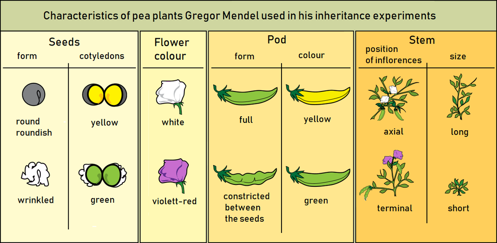

[LadyofHats/Wikimedia](https://commons.wikimedia.org/wiki/File:Gregor_Mendel_-_characteristics_of_pea_plants_-_english.png)

## Marcadores morfológicos

Mapa construído a partir de marcadores morfológicos:

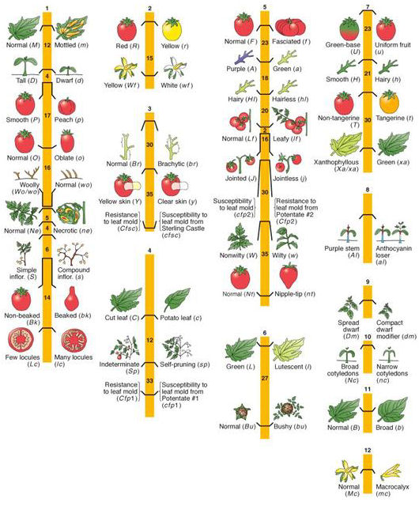

[Griffiths et al. (2002)](https://www.mun.ca/biology/scarr/MGA2-06-17c.html)

## Marcadores moleculares

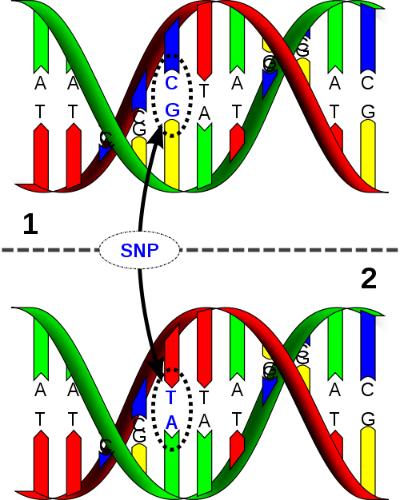

[International Society of Genetic Genealogy](https://isogg.org/wiki/Single-nucleotide_polymorphism)

- Variações no próprio DNA provocadas por mutações
- Frequentes ao longo de todo o genoma
- Estáveis, e não são confundíveis com efeitos do ambiente
- AFLP, RFLP, RAPD, SSR, SNPs…

## Marcadores moleculares

Mapa de ligação de morango baseado em SNPs:

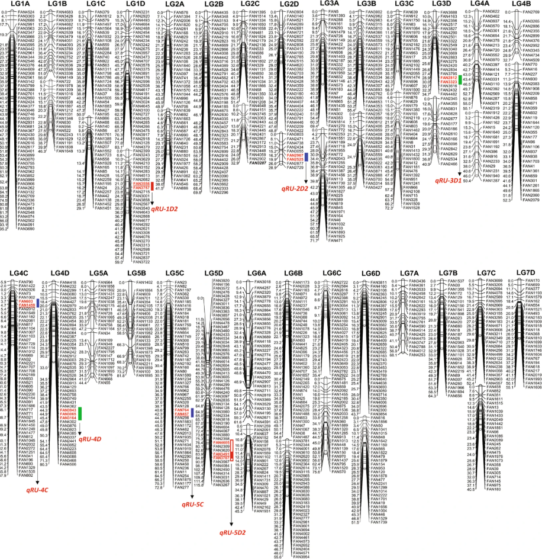

[Hossain et al. (2019)](https://www.nature.com/articles/s41598-019-39808-9)

# Apanhado geral

## Vimos hoje

O cruzamento-teste de três pontos é eficiente em estimar a frequência de recombinação e construir mapas genéticos pois facilita o ordenamento entre locos e a identificação de duplos-recombinantes

[figure not shown]

## Vimos hoje

Os *crossing-overs* inibem uns aos outros de um modo semelhante a uma interação, fenômeno denominado interferência

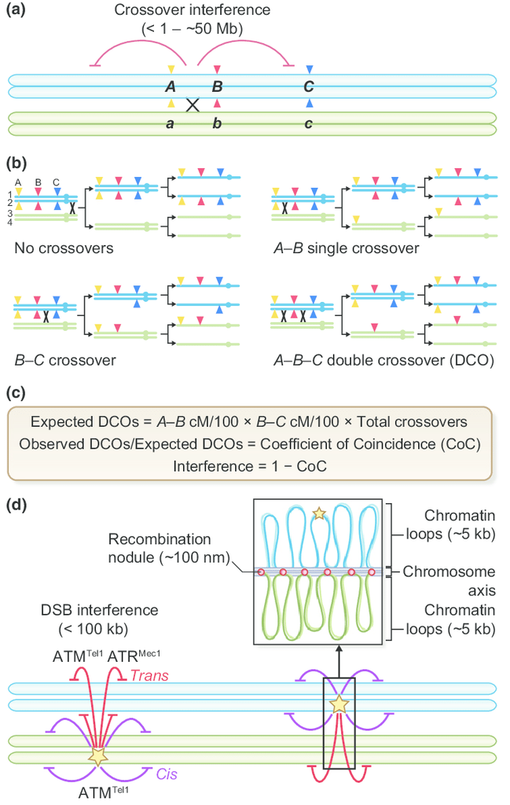

[Ziolkowski & Henderson (2016)](https://www.researchgate.net/publication/310175812_Interconnections_between_meiotic_recombination_and_sequence_polymorphism_in_plant_genomes)

## Vimos hoje

Marcadores genéticos são marcos que indicam a existência de variações (polimorfismos) no DNA. Podem ser morfológicos ou moleculares, sendo estes, mais abundantes e eficientes em indicar variação

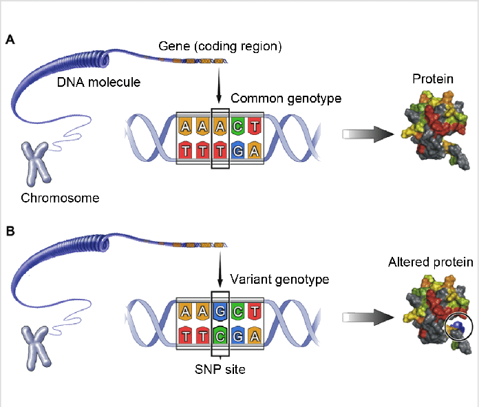

[Iglesias & Grzelczak (2020)](https://www.researchgate.net/publication/338958995_Using_gold_nanoparticles_to_detect_single-nucleotide_polymorphisms_toward_liquid_biopsy)

## Para fixação

1. **Por que marcadores moleculares são mais apropriados para construção de mapas genéticos e estudos da herança de características?**
2. Qual a importância da construção dos mapas genéticos? Quais informações eles provêem?
3. No estádio de plântula, uma planta de milho homozigótica para todos os alelos recessivos apresenta fenótipo folhas brilhantes, virescentes e sem lígula. Essa planta foi cruzada com outra heterozigótica para as três características produzindo a seguinte proporção de descendentes:

| Fenótipos | Nº ind. |
| --- | --- |
| Folhas sem brilho, verde, com lígula | 28 |
| Folhas sem brilho, verde, sem lígula | 179 |
| Folhas sem brilho, virescente, com lígula | 69 |
| Folhas sem brilho, virescente, sem lígula | 250 |
| Folhas brilhantes, verde, com lígula | 198 |
| Folhas brilhantes, verde, sem lígula | 70 |
| Folhas brilhantes, virescente, com lígula | 183 |
| Folhas brilhantes, virescente, sem lígula | 23 |

1. Determinar a ordem dos genes e construir o mapa genético envolvendo esses três locos (Folhas brilhantes = **a**, virescentes = **b**, sem lígula = **c**)
2. Calcular o coeficiente de interferência e intepretar os resultados
3. Qual o genótipo da planta heterozigótica usada no cruzamento-teste?

## Material de apoio

- GRIFFITHS, A. J. F., WESSLER, S. R., CARROLL, S. B., & DOEBLEY, J. (2016). Capítulo 4: Mapeamento de cromossomos eucarióticos por recombinação. Introdução à Genética.
- RAMALHO, M. A. P., SANTOS, J. B., & PINTO, C. A. B. P. (2004). Capítulo 9: Ligação, permuta genética e pleiotropia. Genética Na Agropecuária.
- SNUSTAD, D. P., & SIMMONS, M. J. (2010). Capítulo 7: Ligação, crossing-over e mapeamento cromossômico em eucariotos. Fundamentos de Genética.
- [Técnicas inovadoras de melhoramento de precisão](https://www.youtube.com/watch?v=Qp8xUCptJao)
- [Genômica no melhoramento florestal](https://www.youtube.com/watch?v=uO3vYx0WzPI)
- [Testes de dois e três pontos](https://opengenetics.pressbooks.tru.ca/chapter/mapping-with-three-point-crosses/)